# Spatial Upscaling

Report Exercise

Emma Biland

```r
#Load libraries
library(dplyr);library(ggplot2);library(recipes);library(caret);library(ranger);library(gridExtra);library(readr);library(purrr);library(rnaturalearth);library(tidyr)
```

### Introduction

This exercise follows the Spatial Upscaling workflow from the GECO course material and focuses on assessing model performance under different validation strategies when observations are spatially clustered. We use a global dataset of leaf nitrogen concentration (leafN) distributed via the `leafnp_data` repository (Stocker & Tian, 2024). The data include site coordinates and environmental covariates, enabling both random and spatially structured cross-validation. We specifically compare random, spatial and encironmental cross-validation.

```r
# Load Data
df <- read_csv("https://raw.githubusercontent.com/geco-bern/leafnp_data/main/data/leafnp_tian_et_al.csv")

common_species <- df |>
  group_by(Species) |>
  summarise(count = n()) |>
  arrange(desc(count)) |>
  slice(1:50) |>
  pull(Species)

dfs <- df |>
  select(leafN, lon, lat, elv, mat, map, ndep, mai, Species) |>
  filter(Species %in% common_species)

#for reproducibility
set.seed(42)
```

## 1. Literature

Based on the text of Ludwig et al. (2023)

### 1.1. Difference between random and spatial cross-validation

Random cross-validation ignores the spatial structure of the data. When observations are spatially clustered, nearby samples tend to have similar environmental conditions. Randomly assigning points to folds therefore leads to training and test sets that are geographically close. This inflates model performance because the model is evaluated on locations that are very similar to the training data.

Spatial cross-validation groups samples into geographically separated clusters and uses these clusters as folds. This breaks the spatial autocorrelation between training and validation data. As a result, performance estimates are more realistic for spatial upscaling, where the model must predict in regions that are environmentally or geographically distinct from the calibration locations. Spatial CV typically yields lower accuracy, but the estimates are more relevant for prediction in new areas.

### 1.2. Alternative distance measures for spatial upscaling

Yes. Instead of defining distance in geographic space, distance can be computed in environmental space, using variables such as mean annual temperature, precipitation, nitrogen deposition, or radiation. Clustering points based on environmental similarity groups sites that share comparable ecological conditions, which is often more relevant for upscaling than geographic proximity. This approach reflects the structure of the predictor space rather than the spatial location.

## 2. Random cross-validation

```r
# Model recipe:
# - leafN as response
# - elv, mat, map, ndep, mai, Species as predictors

rf_recipe_random <- recipe(
leafN ~ elv + mat + map + ndep + mai + Species,
data = dfs
) |>
step_center(all_numeric(), -all_outcomes()) |>
step_scale(all_numeric(), -all_outcomes()) |>
step_dummy(all_nominal(), one_hot = TRUE) |>
step_zv(all_predictors())

# Random forest with 5-fold random cross-validation

rf_random <- train(
rf_recipe_random,
data   = dfs |> drop_na(),
method = "ranger",
trControl = trainControl(
method = "cv",
number = 5,
savePredictions = "final"
),
tuneGrid = expand.grid(
.mtry          = 3,
.splitrule     = "variance",
.min.node.size = 12
),
metric = "RMSE",
replace = FALSE,
sample.fraction = 0.5,
num.trees = 2000
)

rf_random
```

```
## Random Forest
##
## 22472 samples
##     8 predictor
##
## Recipe steps: center, scale, dummy, zv
## Resampling: Cross-Validated (5 fold)
## Summary of sample sizes: 17978, 17978, 17978, 17977, 17977
## Resampling results:
##
##   RMSE      Rsquared   MAE
##   3.114947  0.6866947  2.215968
##
## Tuning parameter 'mtry' was held constant at a value of 3
## Tuning
##  parameter 'splitrule' was held constant at a value of variance
##
## Tuning parameter 'min.node.size' was held constant at a value of 12
```

```r
random_cv_metrics <- rf_random$resample |>
dplyr::summarise(
rmse_mean = mean(RMSE),
rmse_sd   = sd(RMSE),
r2_mean   = mean(Rsquared),
r2_sd     = sd(Rsquared)
)

random_cv_metrics
```

```
##   rmse_mean    rmse_sd   r2_mean      r2_sd
## 1  3.114947 0.04389927 0.6866947 0.01676982
```

The random 5-fold cross-validation provides an estimate of model performance when training and validation samples are drawn at random from the same overall data distribution. For the random forest model, the mean RMSE across the five folds is 3.11 $\text{g N g}^{-1}\text{ DM}$ (standard deviation 0.0439), and the mean $R^2$ is 0.687 (standard deviation 0.0168).

These values indicate how well the model interpolates within the sampled environmental and geographical space. Because training and validation data are often geographically close, these metrics are expected to be optimistic compared to validation schemes that explicitly account for spatial structure.

## 3. Spatial cross-validation

### 3.1. What do you observe on the gobal map of observation sites?

The global distribution of sampling sites is highly uneven. There is strong clustering in Europe and eastern Asia, while Africa, South America, and Australia are very sparsely sampled. This implies that large parts of the global environmental space are poorly represented in the training data. For spatial upscaling, predictions in these regions rely largely on extrapolation, and performance metrics from random CV are likely to overestimate the true predictive skill.

### 3.2. Perform a spatial cross-validation. Plot points on a global map, showing the five clusters with distinct colors.

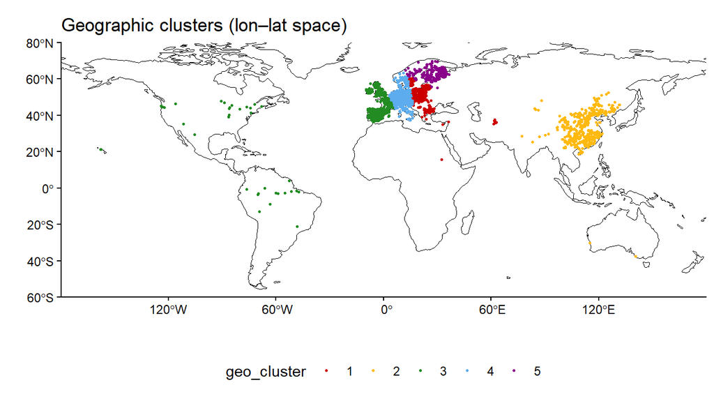

### 3.3. Plot the distribution of leaf N by cluster.

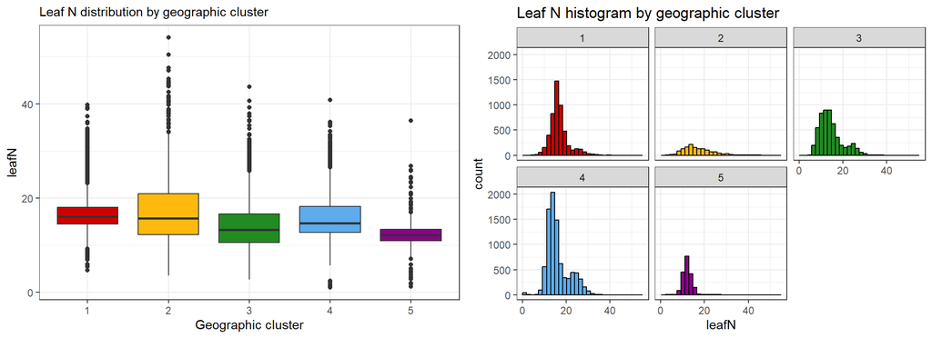

### 3.4. Split your data into five folds that correspond to the geographical clusters identified by in (2.), and fit a random forest model performing a 5-fold cross-validation with the clusters as folds. Report the RMSE and the determined on each of the five folds.

```r
# Create train/test indices from a cluster factor

create_cluster_folds <- function(cluster_factor) {
levels_vec <- levels(cluster_factor)

folds_train <- map(
seq_along(levels_vec),
~ which(cluster_factor != levels_vec[.x])
)

folds_test <- map(
seq_along(levels_vec),
~ which(cluster_factor == levels_vec[.x])
)

list(train = folds_train, test = folds_test)
}

# Fit RF model on one fold pair and return RMSE + R²

fit_rf_by_fold <- function(df, idx_train, idx_val) {

# Exclude response and cluster columns from predictors

predictor_mask <- !(names(df) %in% c("leafN", "geo_cluster", "env_cluster"))

x_train <- df[idx_train, predictor_mask, drop = FALSE]
x_val   <- df[idx_val, predictor_mask, drop = FALSE]

y_train <- df$leafN[idx_train]
y_val   <- df$leafN[idx_val]

rf_model <- ranger(
x = x_train,
y = y_train,
num.trees = 2000,
mtry = 3,
min.node.size = 12,
importance = "none"
)

pred <- predict(rf_model, data = x_val)$predictions

rsq  <- summary(lm(pred ~ y_val))$r.squared
rmse <- sqrt(mean((y_val - pred)^2))

tibble(rsq = rsq, rmse = rmse)
}

# 5-fold spatial cross-validation based on geographic clusters

geo_folds <- create_cluster_folds(dfs$geo_cluster)

cv_results_geo <- map2_dfr(
geo_folds$train,
geo_folds$test,
~ fit_rf_by_fold(dfs, .x, .y)
) |>
mutate(test_fold = 1:5)
cv_results_geo
```

```
## # A tibble: 5 × 3
##       rsq  rmse test_fold
##     <dbl> <dbl>     <int>
## 1 0.508    2.97         1
## 2 0.00490  7.07         2
## 3 0.539    4.32         3
## 4 0.639    3.19         4
## 5 0.200    2.08         5
```

## 4. Environmental Cross Validation

### 4.1. Environmental clustering (MAT–MAP) and global map

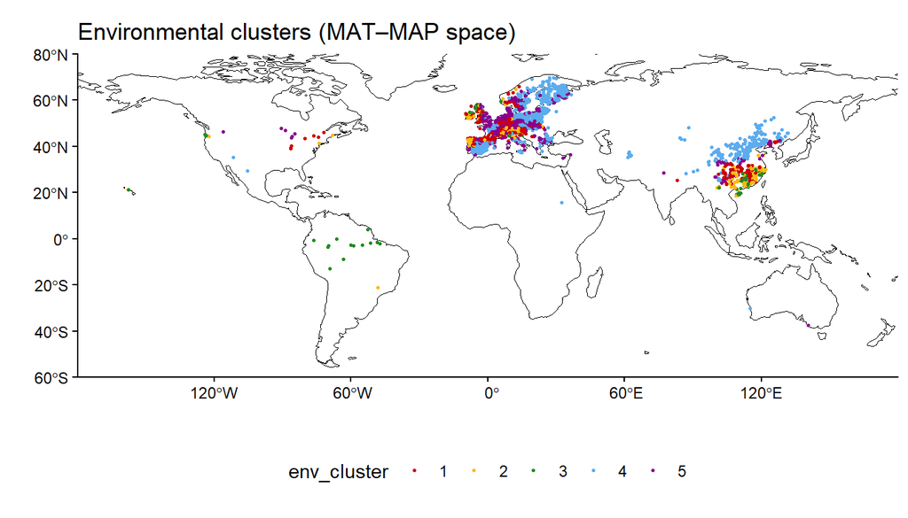

```r
# 5 clusters in environmental space (mean annual temperature and precipitation)

dfs$env_cluster <- as.factor(
kmeans(dfs[, c("mat", "map")], centers = 5)$cluster
)
```

### 4.2. Distribution of leaf N by environmental cluster

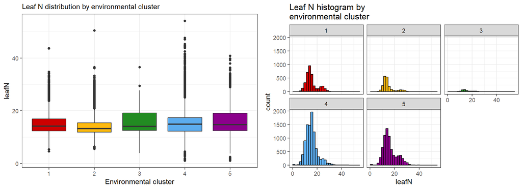

### 4.3. Random Forest with 5-fold environmental CV

```
## # A tibble: 5 × 3
##     rsq  rmse test_fold
##   <dbl> <dbl>     <int>
## 1 0.669  2.88         1
## 2 0.611  3.15         2
## 3 0.583  3.32         3
## 4 0.436  3.66         4
## 5 0.672  3.14         5
```

Environmental spatial cross-validation performs considerably better than geographic spatial cross-validation but worse than random cross-validation. The variation in RMSE and between environmental folds is relatively small, even though the fold sizes differ. This suggests that clustering in environmental space leads to folds that are more homogeneous in terms of predictor variables, and that environmental similarity is more relevant for leaf nitrogen prediction than geographic proximity alone. Environmental CV therefore provides a useful compromise: it avoids the strongly over-optimistic performance estimates from random CV, while remaining more stable than purely geographic CV.

### 5. Conclusion

Random cross-validation gives overly optimistic model performance because training and validation sites are often geographically close. Spatial cross-validation shows much lower accuracy, revealing that the model does not transfer well to distant or poorly sampled regions. Environmental cross-validation performs better and more consistently than geographic CV, indicating that environmental similarity is more relevant than spatial proximity for predicting leaf nitrogen. Overall, spatially explicit validation is essential for realistically assessing model performance in upscaling applications.

### References

Ludwig, Marvin, Alvaro Moreno-Martinez, Norbert Hölzel, Edzer Pebesma, and Hanna Meyer. (2023). Assessing and Improving the Transferability of Current Global Spatial Prediction Models. *Global Ecology and Biogeography 32*(3): 356–68. https://doi.org/10.1111/geb.13635.

Stocker, B. D., & Tian, D. (2024). *geco-bern/leafnp_data: v1.0: Initial release* [Data set]. Zenodo. https://doi.org/10.5281/zenodo.11071944